# Reproducible Research - Peer ASsignment 1

This is a summary of my analysis of the fitness activity data.

The goal was to analyse the total number of steps taken per day and per time interval, over a 2 month period (October and November 2012)l

## Loading and preprocessing the data

For the first part of the analysis, I unzipped the raw data and read the csv-formatted data

```r
fname <- "activity.zip"
if (!file.exists(fname))
    print("Cannot find zip data file in local directory")
unzip(fname)
## After unzipping, read the data in CSV format
activity <- read.csv("activity.csv")
```

## Calculating the mean total number of steps taken per day

For the initial analysis of the data, NA data is ignored. I create a new data structure that just includes the non-NA data, and use that data to plot a histogram that shows the total number of steps taken per day.

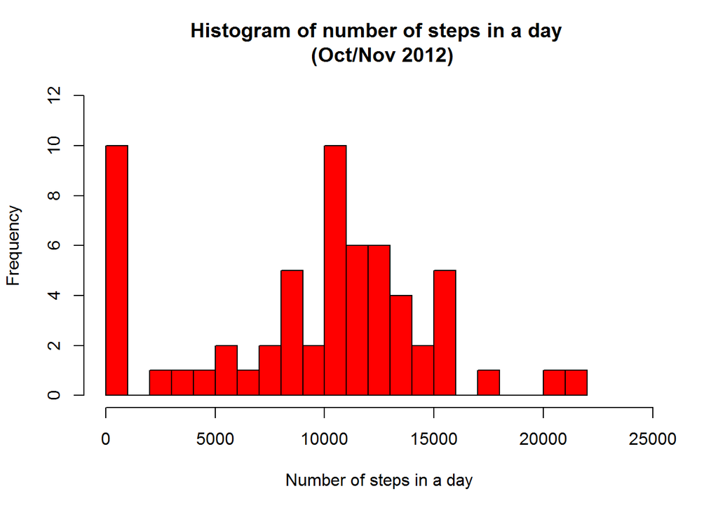

```r
values <- activity[!is.na(activity$steps),]

## Calculate the total number of steps by date
daily_totals <- data.frame(unlist(lapply(split(values, values$date), function(x) sum(x$steps))))
names(daily_totals) <- "total_steps"
hist(as.numeric(daily_totals$total_steps), breaks = 20, xlim = c(0,25000), ylim = c(0,12), col = "red",
    main = "Histogram of number of steps in a day \n (Oct/Nov 2012)",
      xlab = "Number of steps in a day")
```

The histogram shows that there were 10 days when less than 1,000 steps were taken, and only 2 days when more than 20,000 steps were taken.

As a next step, I calculate and report the mean and median values

```r
mn <- mean(daily_totals$total_steps)
print(paste("Mean number of daily steps is", mn))
```

```
## [1] "Mean number of daily steps is 9354.22950819672"
```

```r
md <- median(daily_totals$total_steps)
print(paste("Median number of daily steps is", md))
```

```
## [1] "Median number of daily steps is 10395"
```

The mean number of steps taken in a day is approximately 9354, while the median of the number of daily steps is 10395, as also shown in this updated histogram.

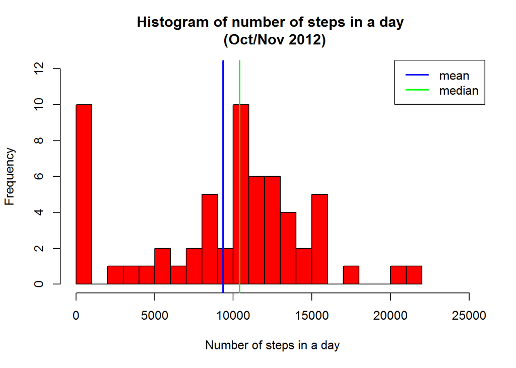

```r
hist(as.numeric(daily_totals$total_steps), breaks = 20, xlim = c(0,25000), ylim = c(0,12), col = "red",
  main = "Histogram of number of steps in a day \n (Oct/Nov 2012)",
  xlab = "Number of steps in a day")
abline(v = mean(daily_totals$total_steps), col = "blue", lwd = 2)
abline(v = median(daily_totals$total_steps), col = "green", lwd = 2)
legend("topright", legend = c("mean","median"),
       col = c("blue", "green"), lwd = 2)
```

## Calculating the average daily activity pattern

Next, I analysed the mean number of steps taken per 5-minute time interval. To correctly display the values, the interval values must be tranformed from integers into time values.

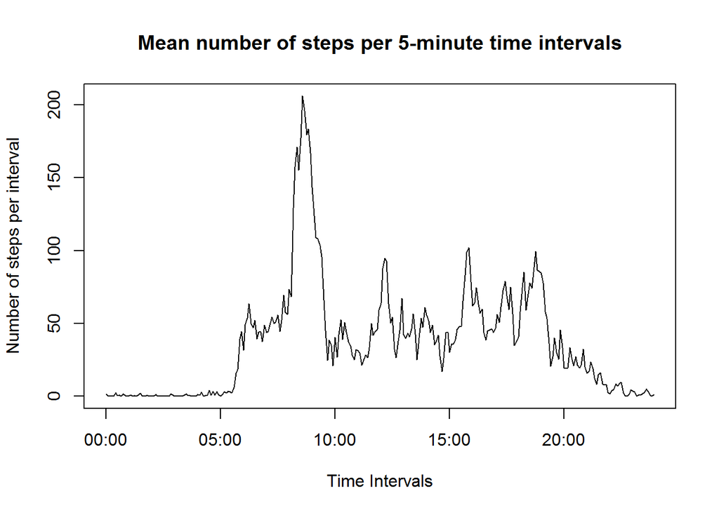

```r
## Calculate the mean number of steps by time interval
interval_means <- data.frame(unlist(lapply(split(values, values$interval), function(x) mean(x$steps))))
names(interval_means) <- "mean_steps"
intervals <- strptime(sprintf("%04d", as.numeric(unique(values$interval))),        format="%H%M")
plot(intervals, as.numeric(interval_means$mean_steps), type = "l",
     xlab = "Time Intervals", ylab = "Number of steps per interval",
     main = "Mean number of steps per 5-minute time intervals")
```

I now calculate the time interval which has the highest mean number of steps.

```r
## Calculate the time interval with the highest number of steps
interval_totals <- data.frame(unlist(lapply(split(values, values$interval), function(x) sum(x$steps))))
names(interval_totals) <- "total_steps"
x <- which.max(interval_totals$total_steps)
y <- max(interval_totals$total_steps)
n <- rownames(interval_totals)
max <- strptime(sprintf("%04d", as.numeric(n[x])), format="%H%M")
t <- as.POSIXlt(max)
print(paste("Time interval with highest total number of steps is ",t$hour,":", t$min, sep=""))
```

```
## [1] "Time interval with highest total number of steps is 8:35"
```

The time interval with the highest total number of steps occurs at 8:35. 10927 steps were taken in total during that time interval over the observed period.

## Imputing missing values

In the analysis so far, I have ignored time intervals that contained NA values.

```r
## How many time intervals have NA values ?
s <- sum(is.na(activity$steps))
print(paste("There are",s,"time intervals with NA values"))
```

```
## [1] "There are 2304 time intervals with NA values"
```

I create a new data set in which all of NA values are replaced by the mean value for the same interval.

```r
## Replace each NA value by the mean value for the same interval
## on other dates
activity2 <- activity
for (k in 1:nrow(activity2)) {
  if (is.na(activity2[k,"steps"])) {
        t <- activity2[k,"interval"]
        activity2[k,"steps"] <- interval_means[as.character(t),"mean_steps"]
        }
    }
```

We can now draw a histogram of total daily steps, and the mean and median number of daily steps, using the updated data set, to see the impact of replacing NA values with calculated values.

```r
## Calculate the total number of steps by date
daily_totals2 <- data.frame(unlist(lapply(split(activity2, activity2$date), function(x) sum(x$steps))))
names(daily_totals2) <- "total_steps"
mn2 <- mean(daily_totals2$total_steps)
print(paste("Mean number of daily steps is", mn2))
```

```
## [1] "Mean number of daily steps is 10766.1886792453"
```

```r
md2 <- median(daily_totals2$total_steps)
print(paste("Median number of daily steps is", md2))
```

```
## [1] "Median number of daily steps is 10766.1886792453"
```

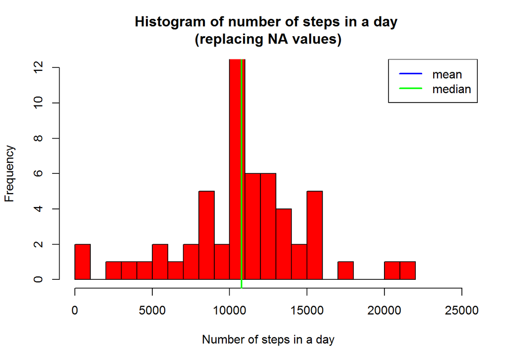

```r
hist(as.numeric(daily_totals2$total_steps), breaks = 20, xlim = c(0,25000), ylim = c(0,12), col = "red",
    main = "Histogram of number of steps in a day \n(replacing NA values)",
    xlab = "Number of steps in a day")
abline(v = mn2, col = "blue", lwd = 2)
abline(v = md2, col = "green", lwd = 2)
legend("topright", legend = c("mean","median"),
       col = c("blue", "green"), lwd = 2)
```

We can see that, having replaced the NA values with calculated values, the mean number of steps taken in a day has increased to approximately 10766, while the median of the number of daily steps is identical to the mean (10766) Also, there are now only 2 days with fewer than 1000 steps.

## Comparing activity patterns on weekdays and weekends

For the final part of the analysis, I split the data set into weekdays (Monday to Friday) and weekends (Saturday and Sunday), to see if average daily activity pattern different between weekdays and weekends.

```r
## Define a function to determine the day of the week
wd <- function(x) if(weekdays(as.Date(x)) %in% c("Saturday", "Sunday"))
  "WEEKEND" else "WEEKDAY"

## Split the updated data set by weekday and weekend
activity2$wd <- lapply(activity2$date, wd)
options(stringsAsFactors = TRUE)
wd_activity <- activity2[(activity2$wd == "WEEKDAY"),]
we_activity <- activity2[(activity2$wd == "WEEKEND"),]
```

Now re-draw the mean number of steps per time interval for those two subsets.

This is the plot for weekdays …

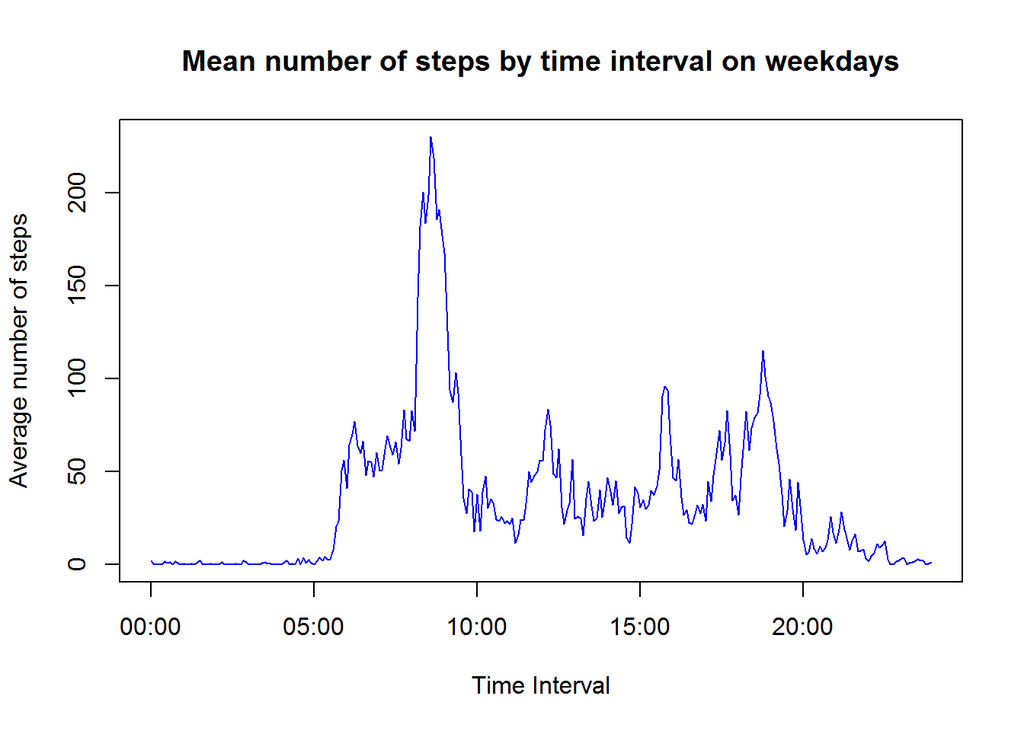

```r
## Now, redraw the two plots for weekdays and weekends

wd_means <- data.frame(unlist(lapply(split(wd_activity, wd_activity$interval), function(x) mean(x$steps))))
names(wd_means) <- "mean_steps"
plot(intervals, as.numeric(wd_means$mean_steps), type = "l", col = "blue",
     main = "Mean number of steps by time interval on weekdays",
     xlab = "Time Interval", ylab = "Average number of steps")
```

And this is the plot for weekends …

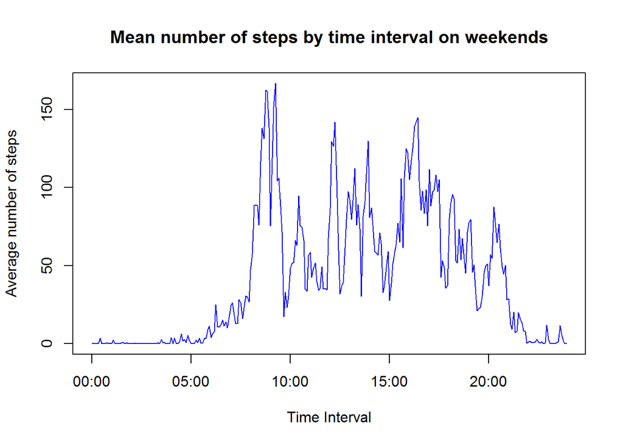

```r
we_means <- data.frame(unlist(lapply(split(we_activity, we_activity$interval), function(x) mean(x$steps))))
names(we_means) <- "mean_steps"
plot(intervals, as.numeric(we_means$mean_steps), type = "l", col = "blue",
     main = "Mean number of steps by time interval on weekends",
     xlab = "Time Interval", ylab = "Average number of steps")
```

As we can see, the average daily activity pattern has shifted to the right (i.e. to later in the day) on weekend days, compared to weekdays.